# simon-5501-11-slides

2026-11-03

## Topics to be covered

- What you will learn
  - Analysis of variance is linear regression
  - R code for analysis of variance
  - Log transformation
  - R code for analysis of variance
  - Kruskal-Wallis test
  - R code for analysis of variance
  - Your homework

## Indicator variables, 1

- Review with two category levels
  - R assigns 0 to first category (alphabetically)
  - R assigns 1 to second category
  - Examples:
    - Female=0, Male=1
    - Man=0, Woman=1

## Indicator variables, 2

- Interpretation
  - Intercept is estimated average outcome for first category
  - Slope is the estimated average change
    - Second category average minus first category average

## Example: Turtle experiment, 1

```
Sex     Fed  Fasted10  Fasted20
Male   42.8      42.4      38.9
Male   43.1      42.2      40.3
Male   40.4      40.8      37.5
Male   46.6      45.9      42.9
Female 42.2      42.4      39.7
Female 38.7      38.1      35.8
Female 35.3      34.3      32.3
Female 40.5      40.1      37.3
```

## Turtle experiment, 2

```
Sex     Fed  Fasted10  Fasted20 Indicator
Male   42.8      42.4      38.9         1
Male   43.1      42.2      40.3         1
Male   40.4      40.8      37.5         1
Male   46.6      45.9      42.9         1
Female 42.2      42.4      39.7         0
Female 38.7      38.1      35.8         0
Female 35.3      34.3      32.3         0
Female 40.5      40.1      37.3         0
```

## Indicator variables, 3

- With k levels, you need k-1 indicators
  - First indicator
    - R assigns 1 to second category (alphabetically)
    - R assigns 0 to all other categories
  - Second indicator
    - R assigns 1 to third category (alphabetically)
    - R assigns 0 to all other categories
  - And so on
- Note: the first category in alphabetical order is zero for all indicator variables.

## Example with dietary cracker data

```
Cracker Digested
control 1772.84
bran    1752.63
combo   2121.97
gum     2558.61
gum     2026.91
bran    2047.42
combo   2254.75
control 2353.21
combo   2153.36
gum     2331.19
bran    2547.77
...
```

## Dietary cracker data, first indicator variable

```
Cracker Digested i1
control 1772.84   0
bran    1752.63   0
combo   2121.97   1
gum     2558.61   0
gum     2026.91   0
bran    2047.42   0
combo   2254.75   1
control 2353.21   0
combo   2153.36   1
gum     2331.19   0
bran    2547.77   0
...
```

## Dietary cracker data, second indicator variable

```
Cracker Digested i1 i2
control 1772.84   0  1
bran    1752.63   0  0
combo   2121.97   1  0
gum     2558.61   0  0
gum     2026.91   0  0
bran    2047.42   0  0
combo   2254.75   1  0
control 2353.21   0  1
combo   2153.36   1  0
gum     2331.19   0  0
bran    2547.77   0  0
...
```

## Dietary cracker data, third indicator variable

```
Cracker Digested i1 i2 i3
control 1772.84   0  1  0
bran    1752.63   0  0  0
combo   2121.97   1  0  0
gum     2558.61   0  0  1
gum     2026.91   0  0  1
bran    2047.42   0  0  0
combo   2254.75   1  0  0
control 2353.21   0  1  0
combo   2153.36   1  0  0
gum     2331.19   0  0  1
bran    2547.77   0  0  0
...
```

## Interpretation with multiple indicator variables

- Intercept is estimated average outcome for first category
- First slope is the estimated change
  - Second category average minus first category average
- Second slope is the estimated change
  - Third category average minus first category average
- And so on

## What if you want a different reference category?

Create your own indicator variables

```
dietary |>
  mutate(i1=as.numeric(Cracker=="bran")) |>
  mutate(i2=as.numeric(Cracker=="combo")) |>
  mutate(i3=as.numeric(Cracker=="gum")) -> dietary_1
```

or revise the order using the factor function.

```
new_order <- c("control", "bran", "combo", "gum")
dietary |>
  mutate(Cracker=factor(Cracker, levels=new_order)) -> dietary_2
lm()
```

## Example using fruitfly lifespans, 1

- Experiment with 125 cages
  - Does fruitfly mating affect average male lifespan?
  - Isolate a male fruitfly with
    - one or eight virgin females,
    - one or eight pregnant females, or
    - no females
  - Note: males will not mate with pregnant females

## Example using fruitfly lifespans, 2

- Cages 1-25 have one male fruitfly, no female fruit flies
- Cages 26-50 have one male fruitfly, one pregnant female
- Cages 51-75 have one male fruitfly, one virgin female
- Cages 76-100 have one male fruitfly, eight pregnant females
- Cages 101-125 have one male fruitfly, eight virgin females

## Break #1

- What you have learned
  - Analysis of variance is linear regression
- What’s coming next
  - R code for analysis of variance

## R code for analysis of variance

Refer to part 1 of the program simon-5501-11-demo.qmd.

## Break #2

- What you have learned
  - R code for analysis of variance
- What’s coming next
  - Log transformation

## Analysis of variance model

- Sample 1: $Y_{11}, Y_{12}, \cdots, Y_{1n_1}$ are $N(\mu_1, \sigma)$
- Sample 2: $Y_{21}, Y_{22}, \cdots, Y_{2n_2}$ are $N(\mu_2, \sigma)$
- $\cdots$
- Sample k: $Y_{k1}, Y_{k2}, \cdots, Y_{kn_k}$ are $N(\mu_k, \sigma)$ $\$
- $H_0:\ \mu_1=\mu_2=...=\mu_k$
- $H_1:\ \mu_i \ne \mu_j$ for some i, j

## Violation of assumptions

- Non-normality
- Heterogeneity
- Lack of independence

## When to consider a log transformation

- Only positive values
- Max/min > 3
- Right (positive) skewed distribution
- Groups with larger means have more variation

## How logarithms convert multiplication and division

- $log(a \times b)=log(a)+log(b)$
  - $log(a / b)=log(a)-log(b)$

## The slide rule uses this property

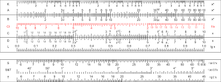

## The book of logarithms

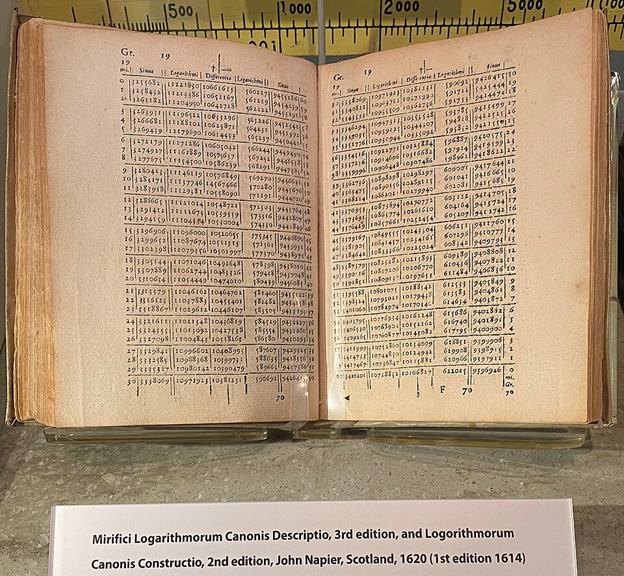

## Interpretation of the back transformed confidence intervals

- A confidence interval is a range of plausible values.
  - A back transformed confidence interval is a range of plausible ratios.
- Does the interval contain the ratio of 1?
  - The two groups are statistically the same.
- Does the interval contain only values larger than 1?
  - The first group is statistically larger
- Does the interval contain only values smaller than 1?
  - The first group is statistically smaller

## Break #3

- What you have learned
  - Log transformation
- What’s coming next
  - R code for analysis of variance

## R code for log transformed analysis of variance

Refer to part 2 of the program simon-5501-11-demo.qmd.

## Break #4

- What you have learned
  - R code for analysis of variance
- What’s coming next
  - Kruskal-Wallis test

## The Chi-squared distribution

- Often denoted as $\chi^2_{df}$
- Has a single parameter, degrees of freedom
  - Never negative
  - Skewed right
  - Mean equals degrees of freedom
- Calculations in R
  - pchisq(x, df) = $P[\chi^2_{df} < x]$
  - qchisq(p, df) = $p^{th}$ quantile, $\chi^2_{df, p}$

## The Chi-squared distribution

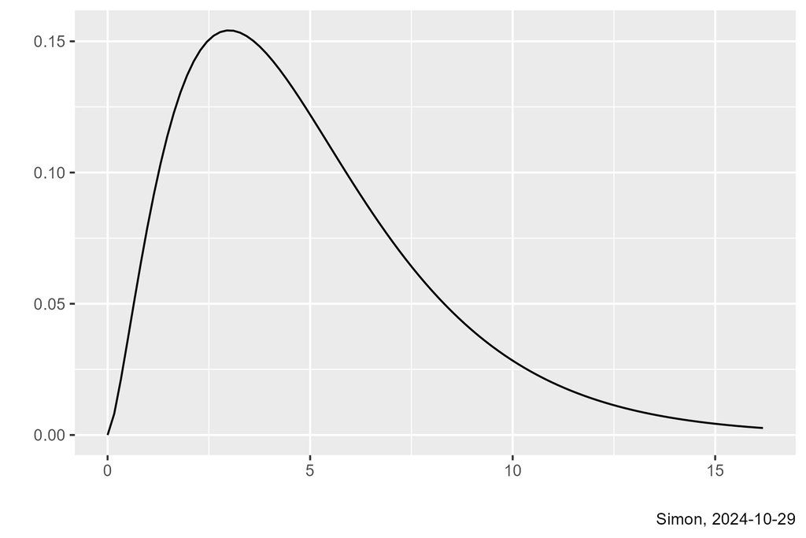

## Decision rules

- T (t-test)
  - Copmpare to the t-distribution
  - Accept H0 if the t-test is close to zero
- F (F-test)
  - Compare to the F distribution
  - Accept HO if the F-test is close to 1
- X2 (chi-squared-test)
  - Compare to the chi-squared distribution
  - Accept HO if the chi-squared test is close to the degrees of freedom

## P-value is easier to remember

- Same diecision rule for any test
  - Accept H0 if the p-value is large
  - Reject H0 if the p-value is small

## Computing the Kruskal-Wallis test

- Rank the observations, $R(X_{ij})$
  - 1 for smallest, 2 for second smallest, etc.
  - Compute the average rank in each group, $\bar{R}_i$
  - Compute the overall rank, $\bar{R}$
  - T = $(N-1)\frac{\Sigma n_i(\bar{R}_i - \bar{R})^2}{\Sigma \Sigma(R(X_{ij})-\bar{R})^2}$

## Decision rule for Kruskal-Wallis test, 1

- Accept $H_0$ if T <- $\chi^2_{df, 1-\alpha}$
  - df = k-1
- Accept $H_0$ if p-value > $\alpha$
  - p-value = $P[\chi^2_{df} > T]$

## Decision rule for Kruskal-Wallis test, 1

- Null hypothesis is difficult to define
  - Does not involve population means
  - Some claim involvement of population medians
  - Stochastic dominance
    - $P[X_{aj} > X_{bj}] > 0.5$ for some a and b.

## Assumptions of the Kruskal-Wallis test

- Homogeneity
- Independence
  - Assessed qualitatively
- Normality is not an assumption

## Advantages and disadvantages of Kruskal-Wallis test

- Advantages
  - No need for normality assumption
  - Still requires homogeneity and independence
  - Not influenced by outliers
- Disadvantages
  - Difficult to get confidence intervals

## Break #5

- What you have learned
  - Kruskal-Wallis test
- What’s coming next
  - R code for analysis of variance

## R code for the Kruskal-Wallis test

Refer to part 3 of the program simon-5501-11-demo.qmd.

## Break #6

- What you have learned
  - R code for analysis of variance
- What’s coming next
  - Your homework

## Your homework

Refer to the file [simon-5501-11-directions](https://github.com/pmean/classes/blob/master/biostats-1/11/src/simon-5501-11-directions.md) on my github site.

## Summary

- What you have learned
  - Analysis of variance is linear regression
  - R code for analysis of variance
  - Log transformation
  - R code for analysis of variance
  - Kruskal-Wallis test
  - R code for analysis of variance
  - Your homework